# Exercise solutions: Section 9.11

Author

Rob J Hyndman and George Athanasopoulos

# fpp3 9.11, Ex2

> A classic example of a non-stationary series are stock prices. Plot the daily closing prices for Amazon stock (contained in `gafa_stock`), along with the ACF and PACF. Explain how each plot shows that the series is non-stationary and should be differenced.

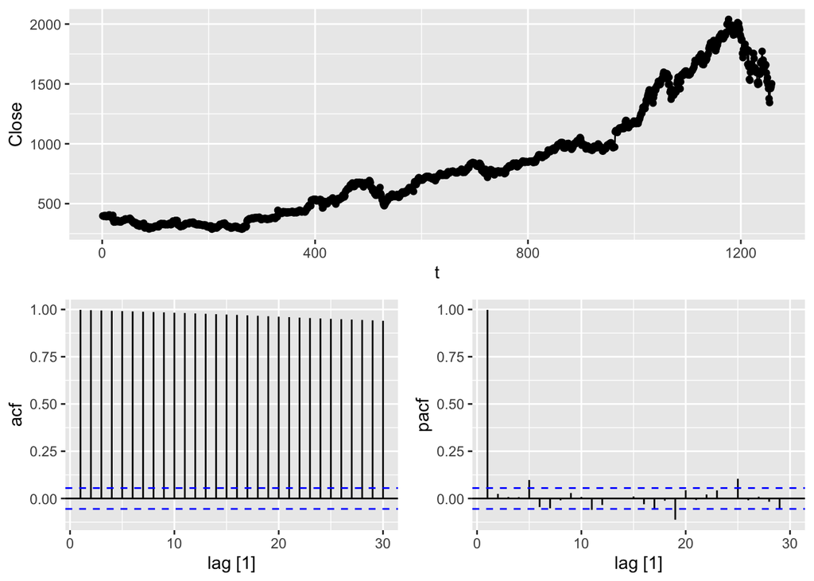

```r
gafa_stock |>
  filter(Symbol == "AMZN") |>
  mutate(t = row_number()) |>
  update_tsibble(index = t) |>
  gg_tsdisplay(Close, plot_type = "partial")
```

- The time plot shows the series “wandering around”, which is a typical indication of non-stationarity. Differencing the series should remove this feature.
- ACF does not drop quickly to zero, moreover the value $r_1$ is large and positive (almost 1 in this case). All these are signs of a non-stationary time series. Therefore it should be differenced to obtain a stationary series.
- PACF value $r_1$ is almost 1. All other values $r_i, i>1$ are small. This is a sign of a non-stationary process that should be differenced in order to obtain a stationary series.

# fpp3 9.11, Ex3

> For the following series, find an appropriate Box-Cox transformation and order of differencing in order to obtain stationary data.
> 1. Turkish GDP from `global_economy`.

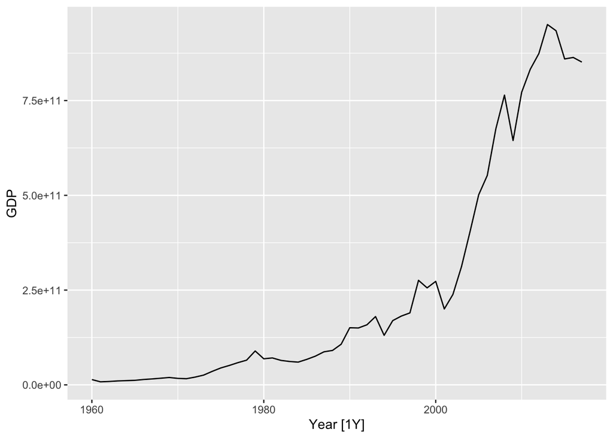

```r
turkey <- global_economy |> filter(Country == "Turkey")
turkey |> autoplot(GDP)
```

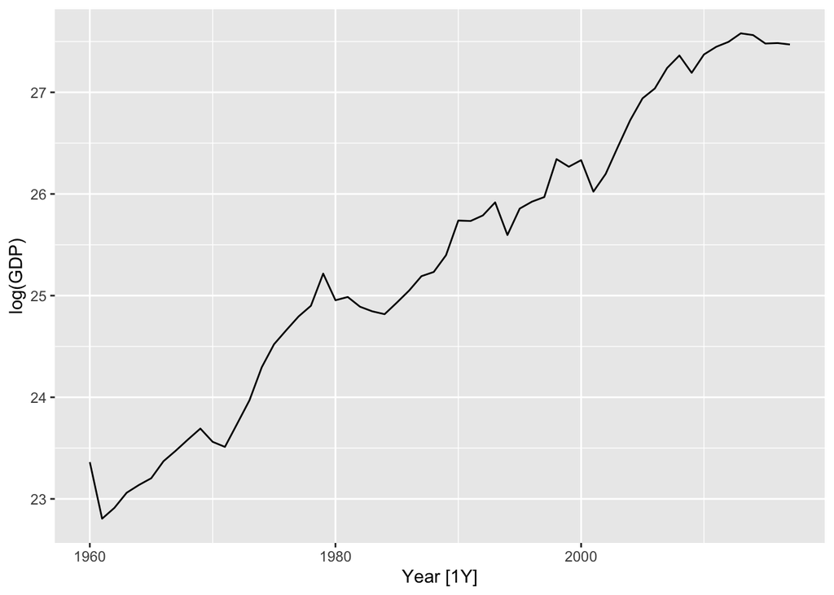

```r
turkey |> autoplot(log(GDP))
```

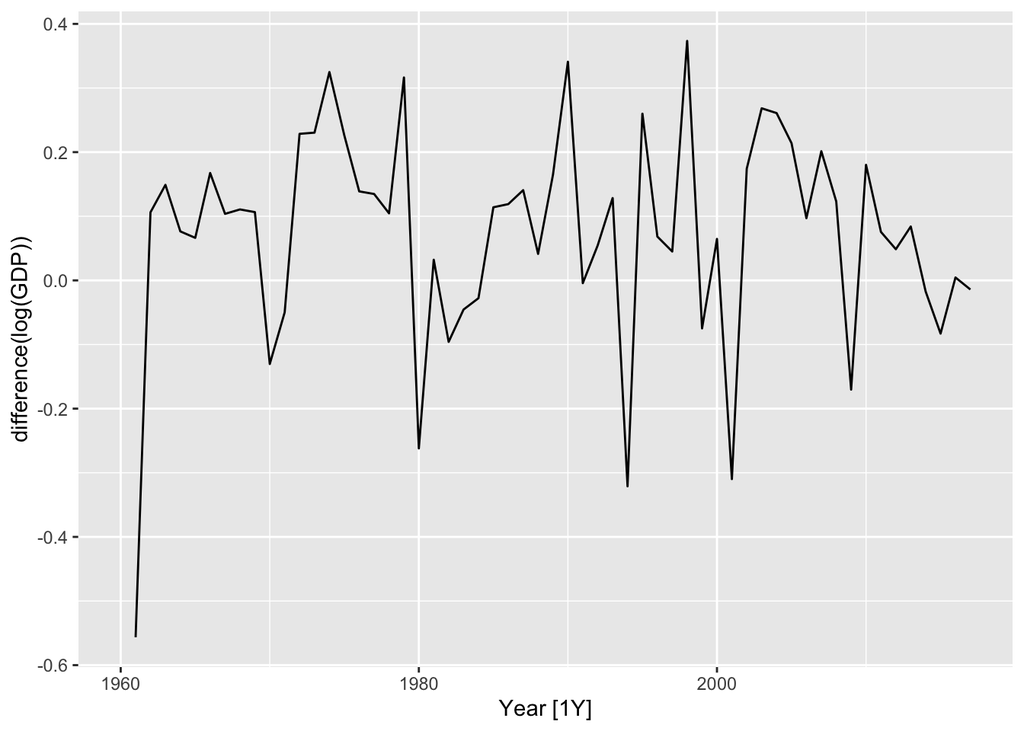

```r
turkey |> autoplot(log(GDP) |> difference())
```

```r
turkey |> features(GDP, guerrero)
```

```
# A tibble: 1 × 2
  Country lambda_guerrero
  <fct>             <dbl>
1 Turkey            0.157
```

- Logs and differences make the data appear stationary.
- Using a Box-Cox transformation with $\lambda$ between 0 and 0.2 would also have worked well.
> 2. Accommodation takings in the state of Tasmania from `aus_accommodation`.

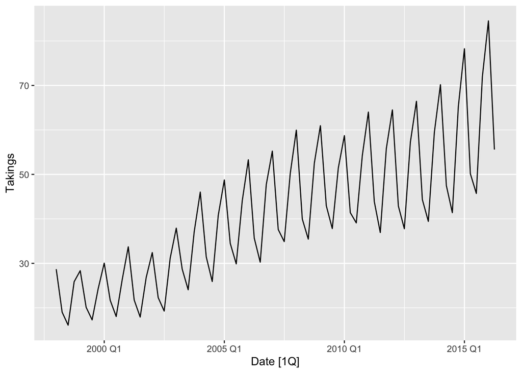

```r
tas <- aus_accommodation |> filter(State == "Tasmania")
tas |> autoplot(Takings)
```

[output not shown]

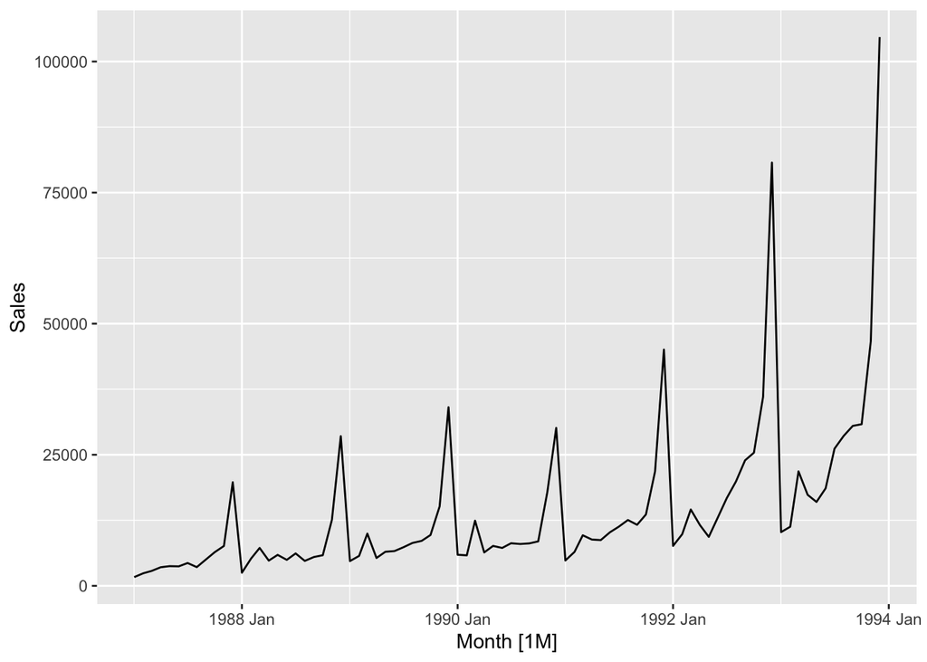

```r
souvenirs |> autoplot(Sales)
```

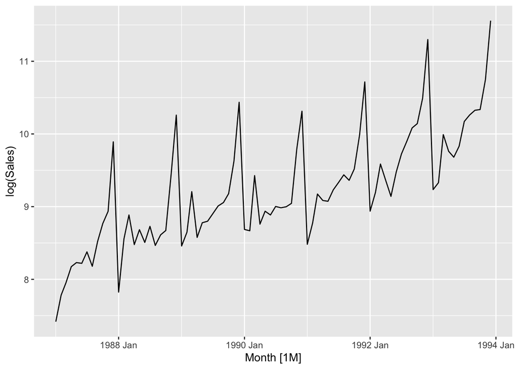

```r
souvenirs |> autoplot(log(Sales))
```

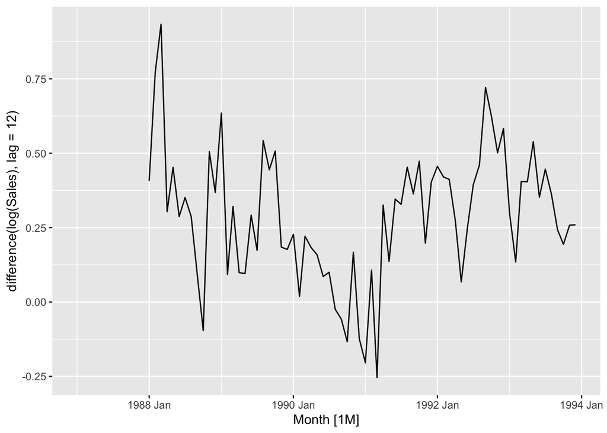

```r
souvenirs |> autoplot(log(Sales) |> difference(lag=12))
```

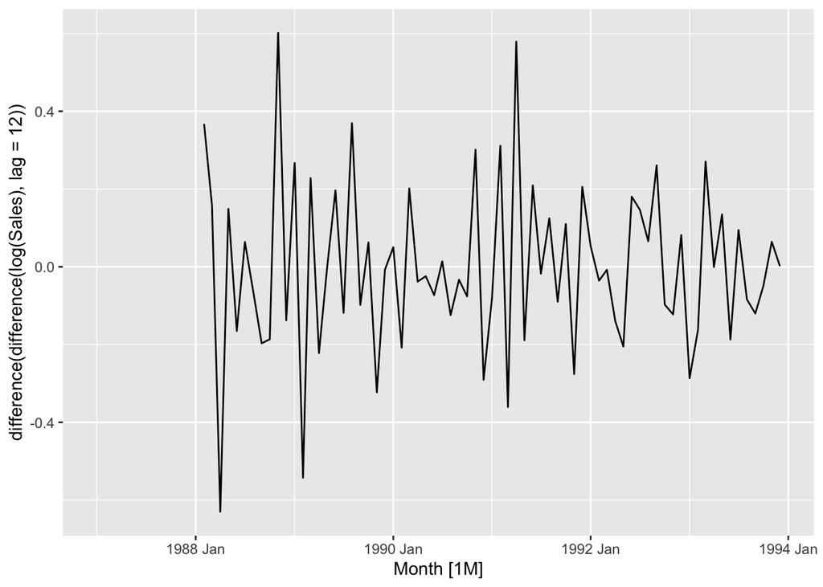

```r
souvenirs |> autoplot(log(Sales) |> difference(lag=12) |> difference())
```

```r
souvenirs |> features(Sales, guerrero)
```

```
# A tibble: 1 × 1
  lambda_guerrero
            <dbl>
1         0.00212
```

- Logs followed by seasonal and first differences make the data appear stationary.
- The automatically selected Box-Cox $\lambda$ value is very close to zero, confirming the choice of using logs.

# fpp3 9.11, Ex4

> For the `souvenirs` data, write down the differences you chose above using backshift operator notation.

Let $y_t =$ log(Sales). Then $(1-B^{12})(1-B)y_t$ gives the differences used above.

# fpp3 9.11, Ex5

> For your retail data (from Exercise 8 in Section 2.10), find the appropriate order of differencing (after transformation if necessary) to obtain stationary data.

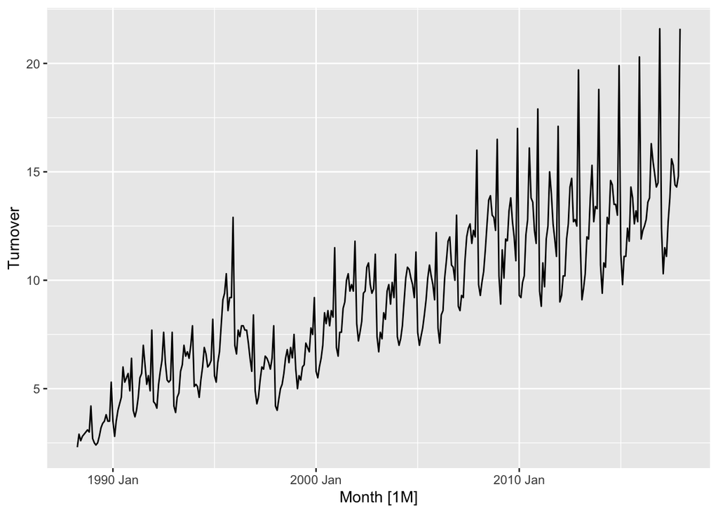

```r
set.seed(12345678)
myseries <- aus_retail |>
  filter(
    `Series ID` == sample(aus_retail$`Series ID`, 1),
    Month < yearmonth("2018 Jan")
  )
myseries |> autoplot(Turnover)
```

Data requires a transformation as the variation is proportional to the level of the series. A log transformation will be okay, although it does seem to be too strong.

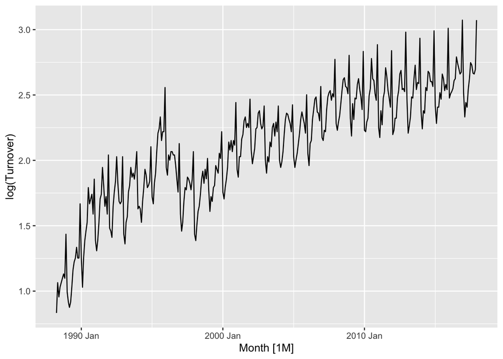

```r
myseries |> autoplot(log(Turnover))
```

Data contains seasonality, so a seasonal difference is required.

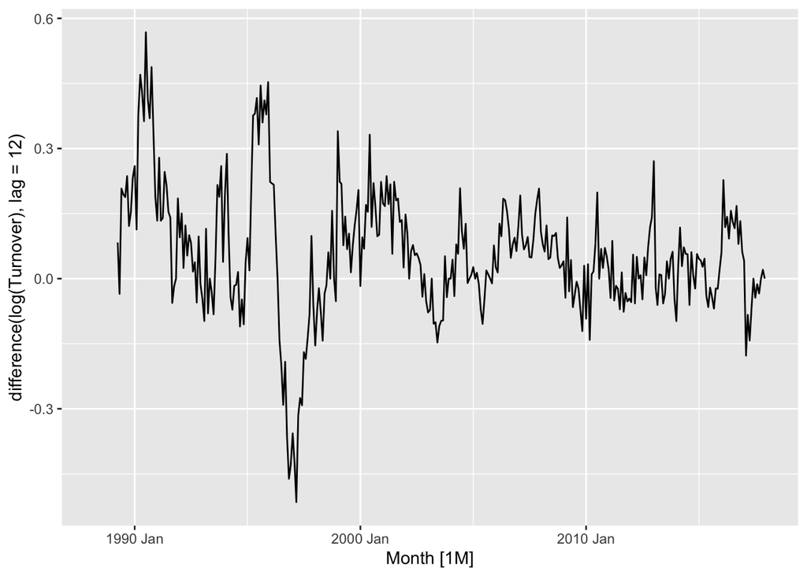

```r
myseries |> autoplot(log(Turnover) |> difference(lag = 12))
```

Data still appears to have extended periods of high values and low values. A first order differencing may be useful.

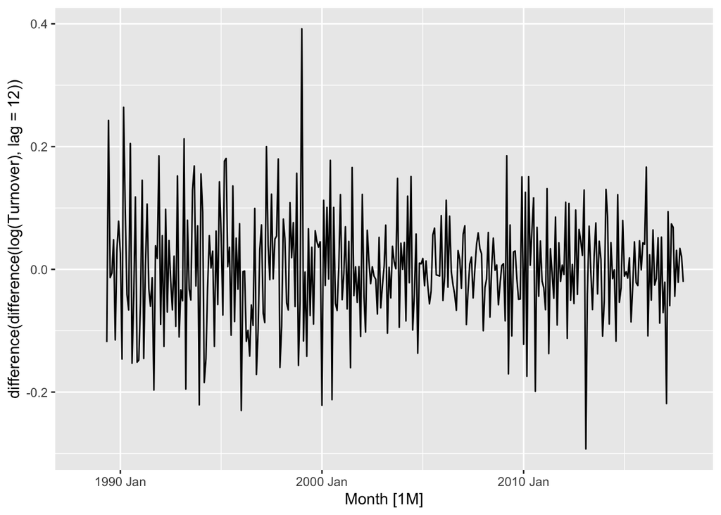

```r
myseries |> autoplot(log(Turnover) |> difference(lag = 12) |> difference())
```